# EDA and Modeling of Health Data

# Logistic Regression

## Model Creation

### First attempt

```r
model <- glm(dstat ~ ., family = binomial, data = train)
print(model)
```

```
##
## Call:  glm(formula = dstat ~ ., family = binomial, data = train)
##
## Coefficients:
## (Intercept)          age       gender           hr        sysbp       diasbp
##   -7.023227     0.059043     0.390544     0.024685    -0.015124    -0.008974
##         bmi          cvd          afb          sho          chf          av3
##   -0.038776    -0.199910    -1.172798     4.209069     0.538755     2.250891
##       miord       mitype         year
##   -0.150135    -0.254022     0.407639
##
## Degrees of Freedom: 312 Total (i.e. Null);  298 Residual
## Null Deviance:       164.4
## Residual Deviance: 101.9     AIC: 131.9
```

Confusion Matrix For Training Data

```r
table(round(predict(model, train, type="response")), train.label)
```

```
##    train.label
##       0   1
##   0 286  16
##   1   4   7
```

Confusion Matrix For Validation Data

```r
table(round(predict(model, validate, type="response")), validate.label)
```

```
##    validate.label
##      0  1
##   0 98  9
##   1  2  3
```

Analysis of Variance

```r
anova(model, test = "Chisq")
```

```
## Analysis of Deviance Table
##
## Model: binomial, link: logit
##
## Response: dstat
##
## Terms added sequentially (first to last)
##
##
##        Df Deviance Resid. Df Resid. Dev  Pr(>Chi)
## NULL                     312     164.36
## age     1  15.1495       311     149.21 9.933e-05 ***
## gender  1   0.0162       310     149.19 0.8988359
## hr      1   0.3166       309     148.88 0.5736295
## sysbp   1  11.6800       308     137.20 0.0006317 ***
## diasbp  1   0.0591       307     137.14 0.8079111
## bmi     1   0.5162       306     136.62 0.4724463
## cvd     1   0.0001       305     136.62 0.9923156
## afb     1   0.5921       304     136.03 0.4415953
## sho     1  29.1392       303     106.89 6.736e-08 ***
## chf     1   0.9849       302     105.91 0.3209950
## av3     1   2.5616       301     103.34 0.1094901
## miord   1   0.0123       300     103.33 0.9117944
## mitype  1   0.0917       299     103.24 0.7619914
## year    1   1.3804       298     101.86 0.2400384
## ---
## Signif. codes:  0 '***' 0.001 '**' 0.01 '*' 0.05 '.' 0.1 ' ' 1
```

### Second Attempt

```r
#verify the data
train <- df[ind == 1, ]
validate <- df[ind == 2, ]
test <- df[ind == 3, ]

cols <- c('age', 'sysbp', 'sho', 'dstat')
train <- train[, cols]
validate <- validate[, cols]
test <- test[, cols]
model <- glm(dstat ~ ., family = binomial, data = train)
print(model)
```

```
##
## Call:  glm(formula = dstat ~ ., family = binomial, data = train)
##
## Coefficients:
## (Intercept)          age        sysbp          sho
##    -6.95191      0.08099     -0.01544      3.38684
##
## Degrees of Freedom: 312 Total (i.e. Null);  309 Residual
## Null Deviance:       164.4
## Residual Deviance: 114.1     AIC: 122.1
```

Evaluation on training data

```r
table(round(predict(model, train, type="response")), train.label)
```

```
##    train.label
##       0   1
##   0 287  16
##   1   3   7
```

Evaluation on validation data

```r
table(round(predict(model, validate, type="response")), validate.label)
```

```
##    validate.label
##       0   1
##   0 100   9
##   1   0   3
```

Evaluation on test data

```r
table(round(predict(model, test, type="response")), test.label)
```

```
##    test.label
##      0  1
##   0 69  4
##   1  2  0
```

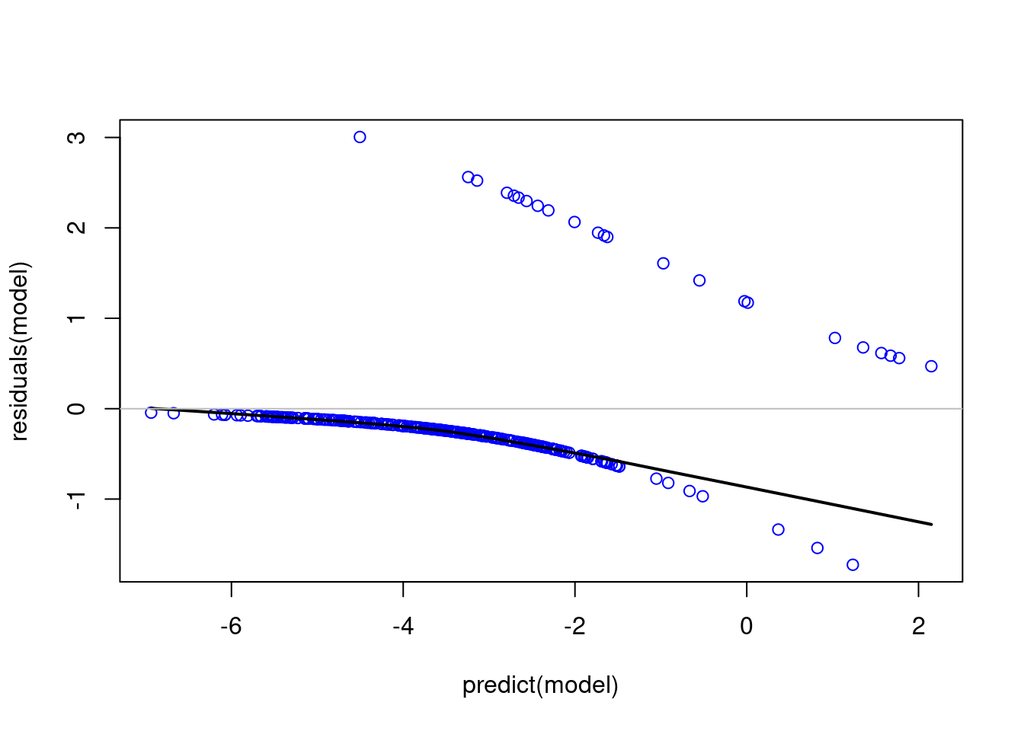

```r
plot(predict(model),residuals(model), col=c("blue"))

lines(lowess(predict(model),residuals(model)), col=c("black"), lwd=2)

abline(h=0, col="grey")
```

### Third Attempt

```r
#verify the data
train <- df[ind == 1, ]
validate <- df[ind == 2, ]
test <- df[ind == 3, ]

model <- glm(dstat ~ ., family = binomial, data = train)
summary(step(model))
```

```
## Start:  AIC=131.86
## dstat ~ age + gender + hr + sysbp + diasbp + bmi + cvd + afb +
##     sho + chf + av3 + miord + mitype + year
##
##          Df Deviance    AIC
## - miord   1   101.92 129.92
## - cvd     1   101.96 129.96
## - mitype  1   101.99 129.99
## - diasbp  1   102.06 130.06
## - bmi     1   102.12 130.12
## - gender  1   102.32 130.32
## - chf     1   102.64 130.64
## - year    1   103.24 131.24
## - sysbp   1   103.67 131.67
## <none>        101.86 131.86
## - afb     1   104.35 132.35
## - av3     1   104.73 132.73
## - hr      1   105.57 133.57
## - age     1   106.75 134.75
## - sho     1   126.93 154.93
##
## Step:  AIC=129.92
## dstat ~ age + gender + hr + sysbp + diasbp + bmi + cvd + afb +
##     sho + chf + av3 + mitype + year
##
##          Df Deviance    AIC
## - mitype  1   102.03 128.03
## - cvd     1   102.05 128.05
## - diasbp  1   102.11 128.11
## - bmi     1   102.16 128.16
## - gender  1   102.39 128.40
## - chf     1   102.67 128.67
## - year    1   103.26 129.26
## - sysbp   1   103.73 129.73
## <none>        101.92 129.92
## - afb     1   104.36 130.35
## - av3     1   104.85 130.85
## - hr      1   105.58 131.57
## - age     1   106.80 132.80
## - sho     1   127.27 153.27
```

[output cut: 104 more lines]

```
## - sysbp  1   109.25 121.25
## - hr     1   111.58 123.58
## - age    1   117.59 129.59
## - sho    1   134.45 146.45
##
## Step:  AIC=119.6
## dstat ~ age + hr + sysbp + sho + av3
##
##         Df Deviance    AIC
## <none>       107.60 119.60
## - av3    1   110.10 120.10
## - sysbp  1   111.00 121.00
## - hr     1   113.01 123.01
## - age    1   119.23 129.23
## - sho    1   134.88 144.88
```

```
##
## Call:
## glm(formula = dstat ~ age + hr + sysbp + sho + av3, family = binomial,
##     data = train)
##
## Deviance Residuals:
##     Min       1Q   Median       3Q      Max
## -1.5886  -0.3402  -0.1850  -0.0992   3.2848
##
## Coefficients:
##              Estimate Std. Error z value Pr(>|z|)
## (Intercept) -9.174140   2.723328  -3.369 0.000755 ***
## age          0.077805   0.025911   3.003 0.002676 **
## hr           0.027129   0.011720   2.315 0.020625 *
## sysbp       -0.017375   0.009761  -1.780 0.075064 .
## sho          3.927907   0.813002   4.831 1.36e-06 ***
## av3          2.181794   1.229345   1.775 0.075937 .
## ---
## Signif. codes:  0 '***' 0.001 '**' 0.01 '*' 0.05 '.' 0.1 ' ' 1
##
## (Dispersion parameter for binomial family taken to be 1)
##
##     Null deviance: 164.36  on 312  degrees of freedom
## Residual deviance: 107.60  on 307  degrees of freedom
## AIC: 119.6
##
## Number of Fisher Scoring iterations: 7
```

```r
cols <- c('age', 'sysbp', 'sho', 'av3', 'hr' ,'dstat')

train <- train[, cols]
validate <- validate[, cols]

model <- glm(dstat ~ ., family = binomial, data = train)
print(model)
```

```
##
## Call:  glm(formula = dstat ~ ., family = binomial, data = train)
##
## Coefficients:
## (Intercept)          age        sysbp          sho          av3           hr
##    -9.17414      0.07781     -0.01738      3.92791      2.18179      0.02713
##
## Degrees of Freedom: 312 Total (i.e. Null);  307 Residual
## Null Deviance:       164.4
## Residual Deviance: 107.6     AIC: 119.6
```

Confusion Matrix For Training Data

```r
table(round(predict(model, train, type="response")), train.label)
```

```
##    train.label
##       0   1
##   0 287  16
##   1   3   7
```

Confusion Matrix For Validation Data

```r
table(round(predict(model, validate, type="response")), validate.label)
```

```
##    validate.label
##      0  1
##   0 98  8
##   1  2  4
```

# References

Goldberg, R. (2001). Worcester Heart Attack Study. [CSV]. Retrieved from https://learn.umgc.edu/content/enforced/685926-027339-01-2225-GO1-9041/Dataset%20Descriptions/whas500.txt

Saraswat (2022). Practical Guide to Logistic Regression Analysis in R. Retrieved from https://www.hackerearth.com/practice/machine-learning/machine-learning-algorithms/logistic-regression-analysis-r/tutorial/

SparkR. (n.d.). GLM: Generalized Linear Models. Retrieved from https://www.rdocumentation.org/packages/SparkR/versions/2.1.2/topics/glm

Stats. (n.d.). Step Choose Model by AIC. Retrieved from https://www.rdocumentation.org/packages/stats/versions/3.6.2/topics/step